# Regression Analysis of NYC Airbnb Data

Shweta Gupta

**For this project I have decided to use The NYC Airbnb dataset from Kaggle.com. I have chosen New York City as it is one of the largest and most popular tourist destinations in the world with a large amount of Airbnb listings.**

**EDA**

The Datset is about Airbnb listings for different hosts in the boroughs of NYC. It Consist of 48895 observatuon with 16 variable. It offers detailed information regarding the price, number of reviews per month and its availability throughout the year.

```
##        id               name              host_id           host_name
##  Min.   :    2539   Length:48895       Min.   :     2438   Length:48895
##  1st Qu.: 9471945   Class :character   1st Qu.:  7822033   Class :character
##  Median :19677284   Mode  :character   Median : 30793816   Mode  :character
##  Mean   :19017143                      Mean   : 67620011
##  3rd Qu.:29152178                      3rd Qu.:107434423
##  Max.   :36487245                      Max.   :274321313
##
##  neighbourhood_group neighbourhood         latitude       longitude
##  Length:48895        Length:48895       Min.   :40.50   Min.   :-74.24
##  Class :character    Class :character   1st Qu.:40.69   1st Qu.:-73.98
##  Mode  :character    Mode  :character   Median :40.72   Median :-73.96
##                                         Mean   :40.73   Mean   :-73.95
##                                         3rd Qu.:40.76   3rd Qu.:-73.94
##                                         Max.   :40.91   Max.   :-73.71
##
##   room_type             price         minimum_nights    number_of_reviews
##  Length:48895       Min.   :    0.0   Min.   :   1.00   Min.   :  0.00
##  Class :character   1st Qu.:   69.0   1st Qu.:   1.00   1st Qu.:  1.00
##  Mode  :character   Median :  106.0   Median :   3.00   Median :  5.00
##                     Mean   :  152.7   Mean   :   7.03   Mean   : 23.27
##                     3rd Qu.:  175.0   3rd Qu.:   5.00   3rd Qu.: 24.00
##                     Max.   :10000.0   Max.   :1250.00   Max.   :629.00
##
##  last_review        reviews_per_month calculated_host_listings_count
##  Length:48895       Min.   : 0.010    Min.   :  1.000
##  Class :character   1st Qu.: 0.190    1st Qu.:  1.000
##  Mode  :character   Median : 0.720    Median :  1.000
##                     Mean   : 1.373    Mean   :  7.144
##                     3rd Qu.: 2.020    3rd Qu.:  2.000
##                     Max.   :58.500    Max.   :327.000
##                     NA's   :10052
##  availability_365
##  Min.   :  0.0
##  1st Qu.:  0.0
##  Median : 45.0
##  Mean   :112.8
##  3rd Qu.:227.0
##  Max.   :365.0
##
```

```
## 'data.frame':    48895 obs. of  16 variables:
##  $ id                            : int  2539 2595 3647 3831 5022 5099 5121 5178 5203 5238 ...
##  $ name                          : chr  "Clean & quiet apt home by the park" "Skylit Midtown Castle" "THE VILLAGE OF HARLEM....NEW YORK !" "Cozy Entire Floor of Brownstone" ...
##  $ host_id                       : int  2787 2845 4632 4869 7192 7322 7356 8967 7490 7549 ...
##  $ host_name                     : chr  "John" "Jennifer" "Elisabeth" "LisaRoxanne" ...
##  $ neighbourhood_group           : chr  "Brooklyn" "Manhattan" "Manhattan" "Brooklyn" ...
##  $ neighbourhood                 : chr  "Kensington" "Midtown" "Harlem" "Clinton Hill" ...
##  $ latitude                      : num  40.6 40.8 40.8 40.7 40.8 ...
##  $ longitude                     : num  -74 -74 -73.9 -74 -73.9 ...
##  $ room_type                     : chr  "Private room" "Entire home/apt" "Private room" "Entire home/apt" ...
##  $ price                         : int  149 225 150 89 80 200 60 79 79 150 ...
##  $ minimum_nights                : int  1 1 3 1 10 3 45 2 2 1 ...
##  $ number_of_reviews             : int  9 45 0 270 9 74 49 430 118 160 ...
##  $ last_review                   : chr  "2018-10-19" "2019-05-21" "" "2019-07-05" ...
##  $ reviews_per_month             : num  0.21 0.38 NA 4.64 0.1 0.59 0.4 3.47 0.99 1.33 ...
##  $ calculated_host_listings_count: int  6 2 1 1 1 1 1 1 1 4 ...
##  $ availability_365              : int  365 355 365 194 0 129 0 220 0 188 ...
```

Lets visualize the missing values in the data

[output not shown]

[output not shown]

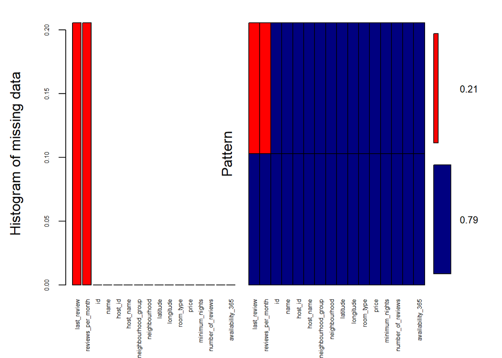

```
##
##  Variables sorted by number of missings:
##                        Variable     Count
##                     last_review 0.2055834
##               reviews_per_month 0.2055834
##                              id 0.0000000
##                            name 0.0000000
##                         host_id 0.0000000
##                       host_name 0.0000000
##             neighbourhood_group 0.0000000
##                   neighbourhood 0.0000000
##                        latitude 0.0000000
##                       longitude 0.0000000
##                       room_type 0.0000000
##                           price 0.0000000
##                  minimum_nights 0.0000000
##               number_of_reviews 0.0000000
##  calculated_host_listings_count 0.0000000
##                availability_365 0.0000000
```

As we can see above, the ‘last_review’ attribute contains only the dates for which the airbnb property was last reviewed or the date when the last review was generated. And if there was no review generated, then there is no date and so we have a missing value in the column.

Neighbourhood group and Room Type

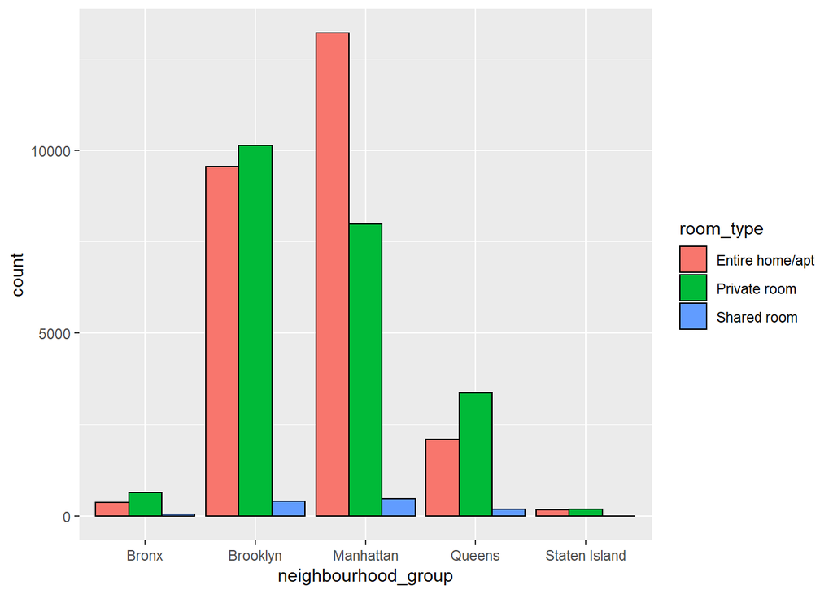

We can see here, that most of the properties fall in the Brooklyn or Manhattan neighbourhood group, while there very few properties in Bronx and Staten Island.Manhattan and Brooklyn being the most popular destination among the toursits. Also, most of the properties are offering either a Private room or the Entire home/apt, there are very few properties which are offering a Shared room. The reason for this can be that most of the tourists or visitors want privacy and prefer either a private room or to have the entire home/apt for themselves for their convenience.

Price Distribution

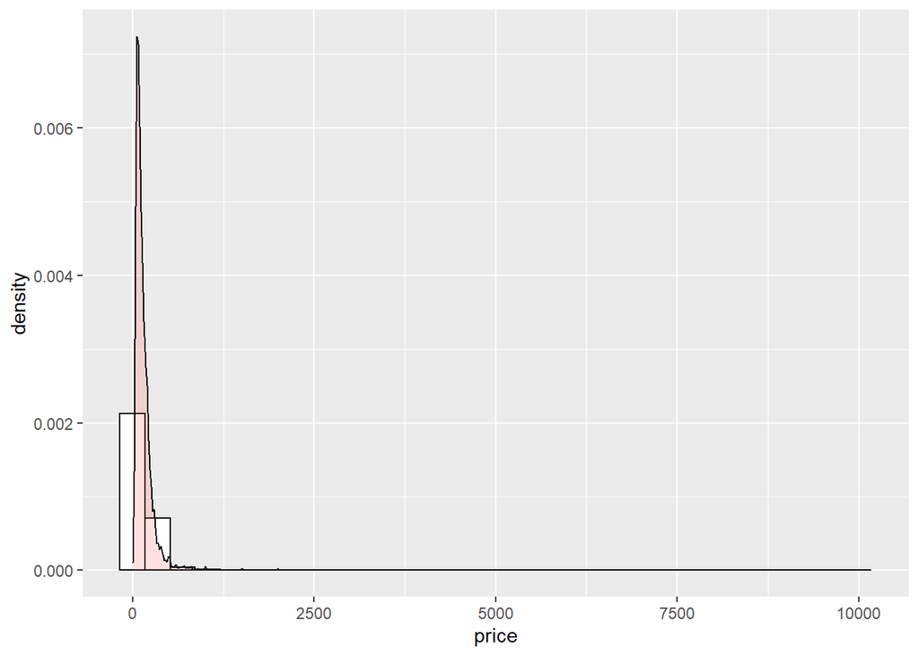

```
##    Min. 1st Qu.  Median    Mean 3rd Qu.    Max.
##     0.0    69.0   106.0   152.7   175.0 10000.0
```

We can observe that prices of listing start from less than 100 and maximum price reaches around 10000. The distribution curve shows that most of listings prices ranges below 500.Also, the price is highly skewed.

Neighbourhood group and Price

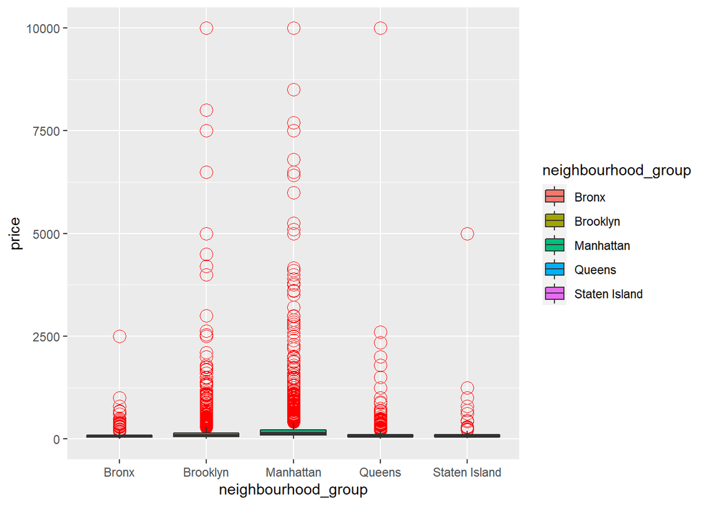

Correlation Matrix  
Analyze the relationship between variables

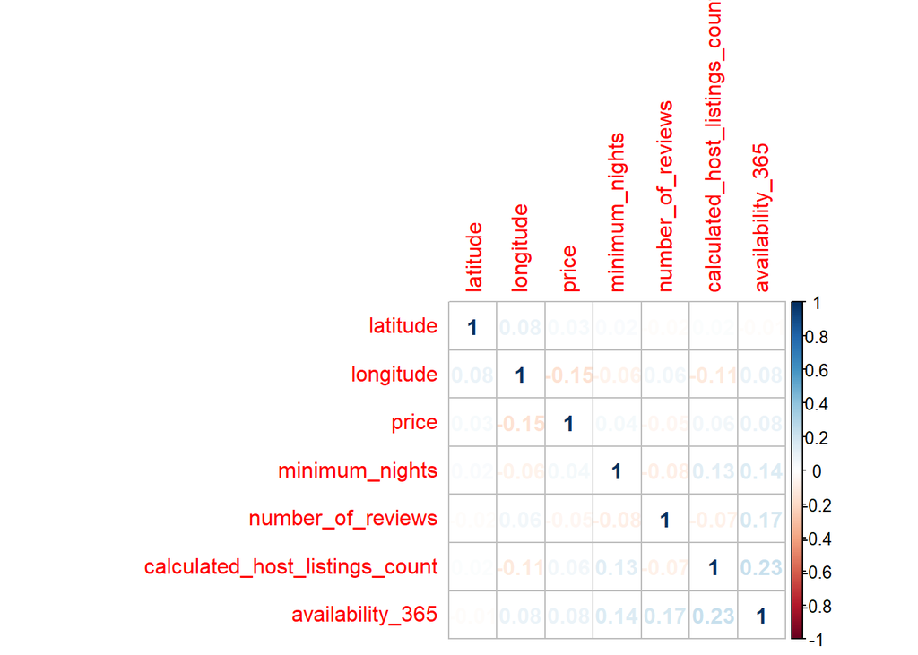

**Feature Engineering**

```
##      price         neighbourhood_group    host_id           room_type
##  Min.   :   10.0   Length:48884        Min.   :     2438   Length:48884
##  1st Qu.:   69.0   Class :character    1st Qu.:  7817310   Class :character
##  Median :  106.0   Mode  :character    Median : 30792574   Mode  :character
##  Mean   :  152.8                       Mean   : 67622035
##  3rd Qu.:  175.0                       3rd Qu.:107434423
##  Max.   :10000.0                       Max.   :274321313
##  minimum_nights    number_of_reviews    latitude       longitude
##  Min.   :   1.00   Min.   :  0.00    Min.   :40.50   Min.   :-74.24
##  1st Qu.:   1.00   1st Qu.:  1.00    1st Qu.:40.69   1st Qu.:-73.98
##  Median :   3.00   Median :  5.00    Median :40.72   Median :-73.96
##  Mean   :   7.03   Mean   : 23.27    Mean   :40.73   Mean   :-73.95
##  3rd Qu.:   5.00   3rd Qu.: 24.00    3rd Qu.:40.76   3rd Qu.:-73.94
##  Max.   :1250.00   Max.   :629.00    Max.   :40.91   Max.   :-73.71
##  availability_365 calculated_host_listings_count
##  Min.   :  0.0    Min.   :  1.000
##  1st Qu.:  0.0    1st Qu.:  1.000
##  Median : 45.0    Median :  1.000
##  Mean   :112.8    Mean   :  7.145
##  3rd Qu.:227.0    3rd Qu.:  2.000
##  Max.   :365.0    Max.   :327.000
```

**Linear regression to predict price**

```
##
## Call:
## lm(formula = price ~ ., data = traindata)
##
## Residuals:
##    Min     1Q Median     3Q    Max
## -251.6  -63.7  -24.0   17.0 9853.7
##
## Coefficients:
##                                    Estimate Std. Error t value Pr(>|t|)
## (Intercept)                      -2.859e+04  3.713e+03  -7.699 1.41e-14 ***
## neighbourhood_groupBrooklyn      -3.231e+01  1.009e+01  -3.203 0.001361 **
## neighbourhood_groupManhattan      3.260e+01  9.114e+00   3.577 0.000348 ***
## neighbourhood_groupQueens        -4.921e+00  9.684e+00  -0.508 0.611386
## neighbourhood_groupStaten Island -1.484e+02  1.914e+01  -7.753 9.21e-15 ***
## host_id                           7.124e-08  1.622e-08   4.391 1.13e-05 ***
## room_typePrivate room            -1.070e+02  2.496e+00 -42.871  < 2e-16 ***
## room_typeShared room             -1.465e+02  8.019e+00 -18.271  < 2e-16 ***
## minimum_nights                   -3.263e-02  6.203e-02  -0.526 0.598886
## number_of_reviews                -2.887e-01  2.776e-02 -10.400  < 2e-16 ***
## latitude                         -2.248e+02  3.617e+01  -6.215 5.17e-10 ***
## longitude                        -5.129e+02  4.166e+01 -12.313  < 2e-16 ***
## availability_365                  1.913e-01  9.901e-03  19.320  < 2e-16 ***
## calculated_host_listings_count   -2.198e-01  3.908e-02  -5.625 1.87e-08 ***
## ---
## Signif. codes:  0 '***' 0.001 '**' 0.01 '*' 0.05 '.' 0.1 ' ' 1
##
## Residual standard error: 227.7 on 36649 degrees of freedom
## Multiple R-squared:  0.1016, Adjusted R-squared:  0.1013
## F-statistic: 318.7 on 13 and 36649 DF,  p-value: < 2.2e-16
```

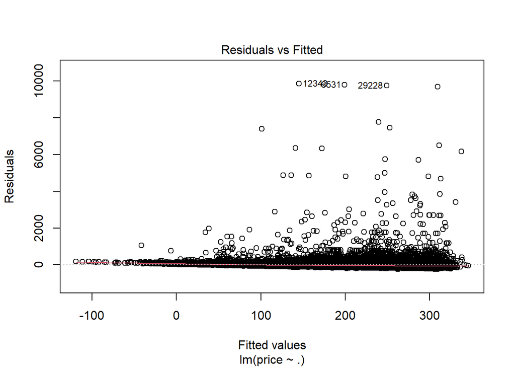

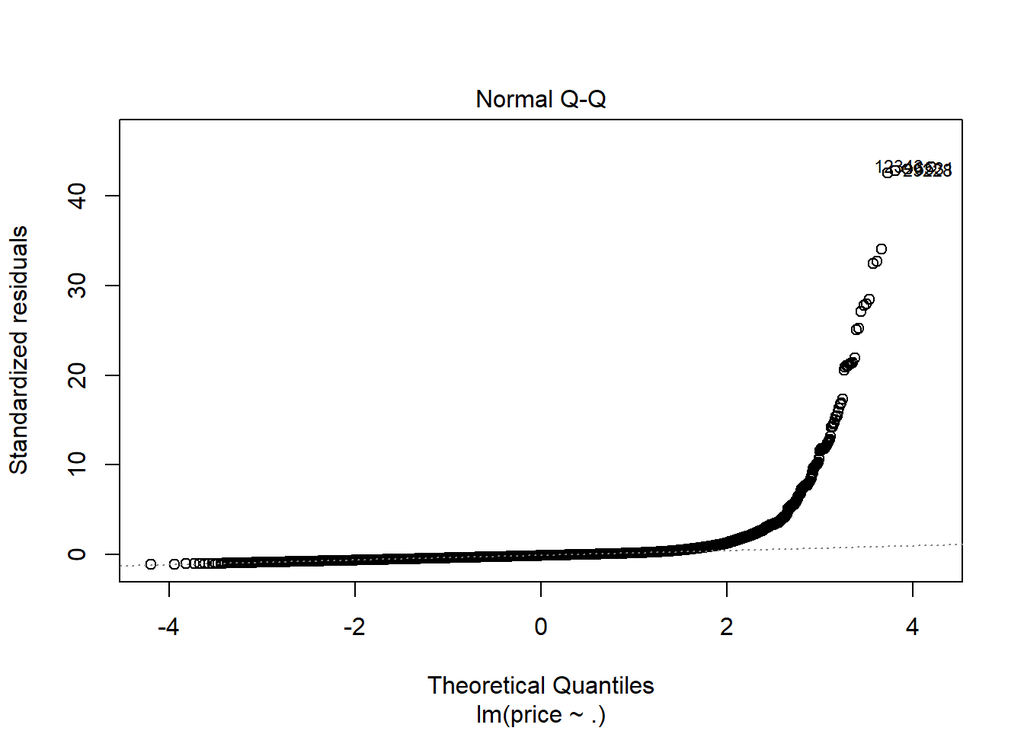

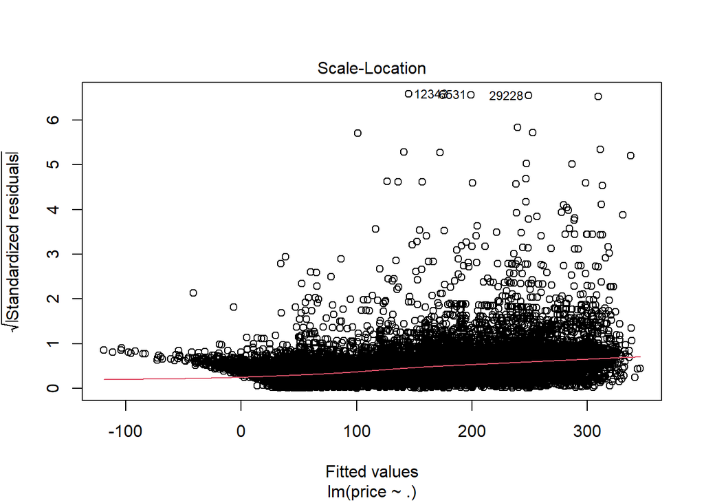

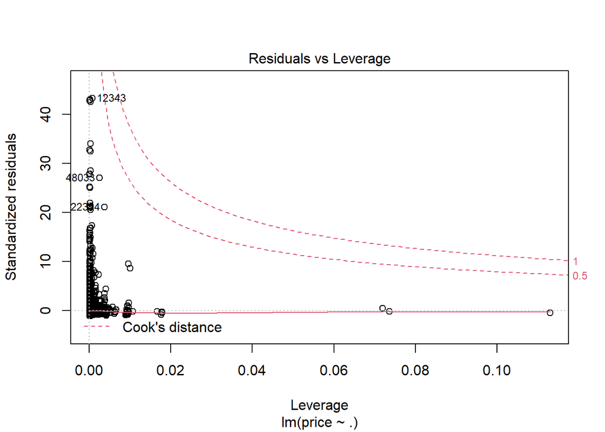

```
## [1] 52482.5
```

```
## [1] 229.0906
```

The model accuracy is very poor which could be attributed to the skewed distribution of the target variable price and therefore will perform log transofrmation on price. Also,would filter out the outliers by considering data which lies in the quantile range of 0.1 to 0.9.

**Linear model with logarithmic transformation**

```
##
## Call:
## lm(formula = log(price) ~ ., data = newtraindata)
##
## Residuals:
##      Min       1Q   Median       3Q      Max
## -1.19057 -0.23134 -0.01591  0.21303  1.66142
##
## Coefficients:
##                                    Estimate Std. Error  t value Pr(>|t|)
## (Intercept)                      -1.211e+02  6.007e+00  -20.161  < 2e-16 ***
## neighbourhood_groupBrooklyn      -3.389e-02  1.720e-02   -1.971  0.04877 *
## neighbourhood_groupManhattan      1.594e-01  1.574e-02   10.124  < 2e-16 ***
## neighbourhood_groupQueens         5.444e-02  1.663e-02    3.273  0.00106 **
## neighbourhood_groupStaten Island -5.415e-01  3.186e-02  -16.994  < 2e-16 ***
## host_id                           5.069e-12  2.679e-11    0.189  0.84992
## room_typePrivate room            -5.373e-01  3.974e-03 -135.199  < 2e-16 ***
## room_typeShared room             -6.075e-01  1.696e-02  -35.827  < 2e-16 ***
## minimum_nights                   -1.365e-03  9.915e-05  -13.766  < 2e-16 ***
## number_of_reviews                -2.942e-04  4.341e-05   -6.778 1.25e-11 ***
## latitude                         -5.048e-01  5.812e-02   -8.686  < 2e-16 ***
## longitude                        -1.981e+00  6.750e-02  -29.352  < 2e-16 ***
## availability_365                  3.403e-04  1.631e-05   20.868  < 2e-16 ***
## calculated_host_listings_count    3.961e-04  6.804e-05    5.822 5.88e-09 ***
## ---
## Signif. codes:  0 '***' 0.001 '**' 0.01 '*' 0.05 '.' 0.1 ' ' 1
##
## Residual standard error: 0.3279 on 29203 degrees of freedom
## Multiple R-squared:  0.4815, Adjusted R-squared:  0.4813
## F-statistic:  2086 on 13 and 29203 DF,  p-value: < 2.2e-16
```

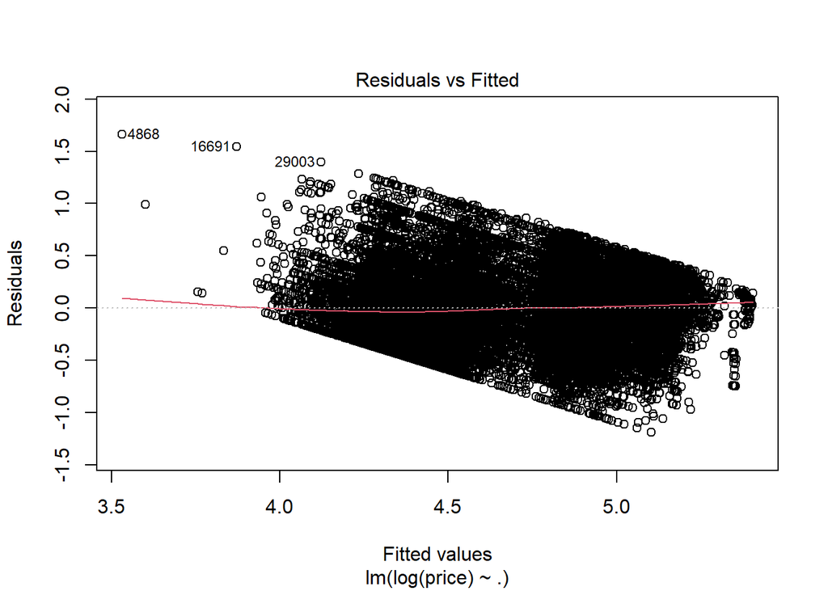

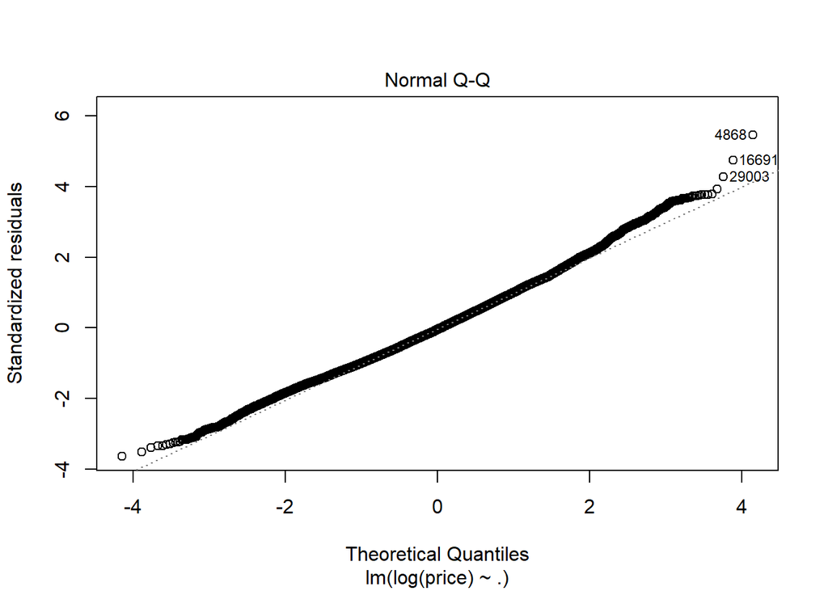

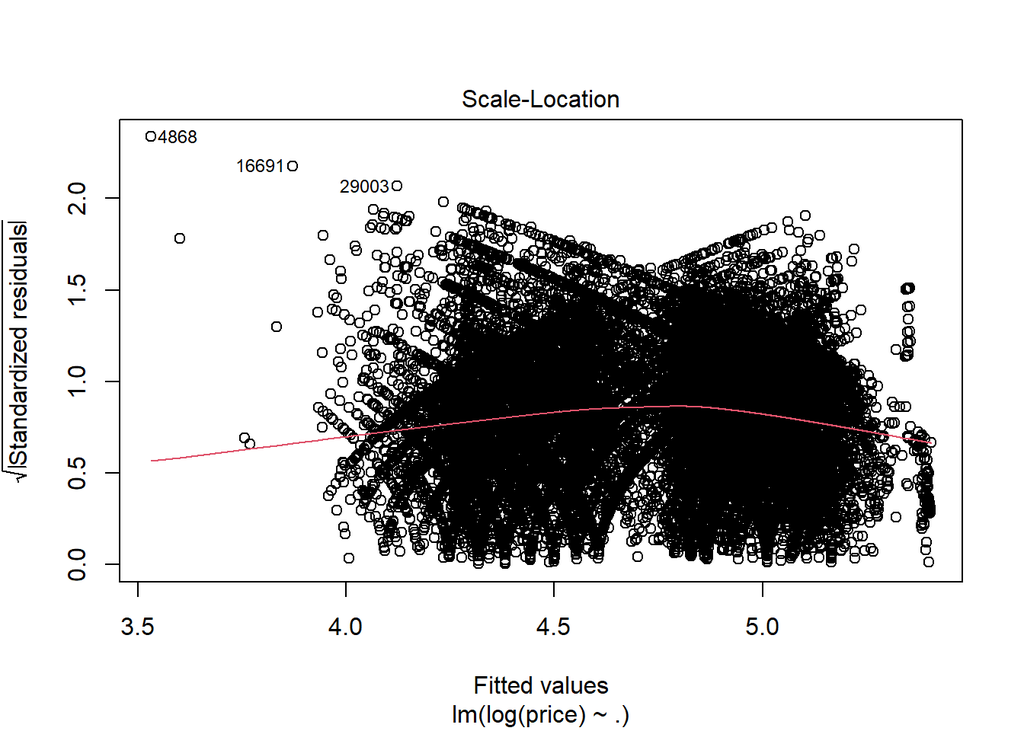

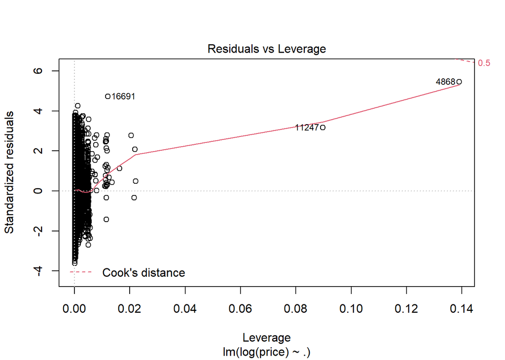

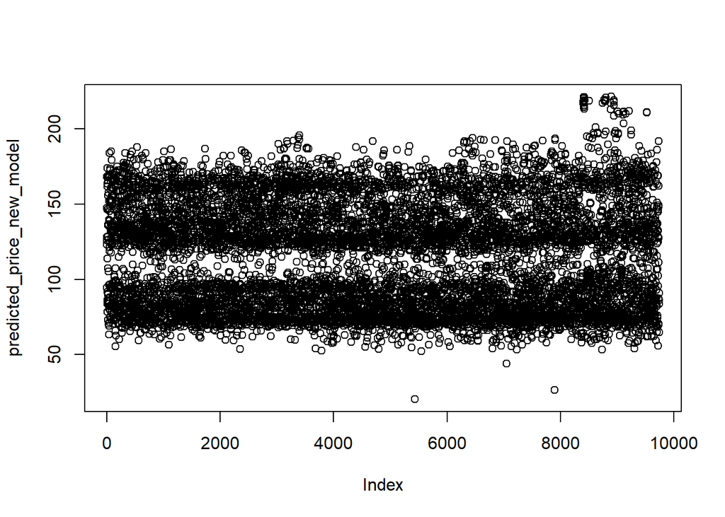

[figure not shown]

```
## [1] 0.4269718
```

```
## [1] 41.92749
```

Plotting the predicted and observed values

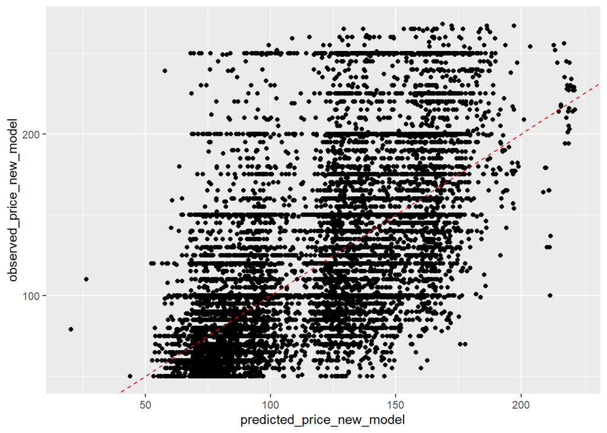

**Ensemble methods**  
Tree based learning algorithms are considered to be one of the best and mostly used supervised learning methods. It empower predictive models with high accuracy, stability and ease of interpretation. Unlike linear models, they map non-linear relationships quite well and are adaptable at solving any kind of problem at hand (classification or regression).  
Encoding Categorical Variables

Decision Tree

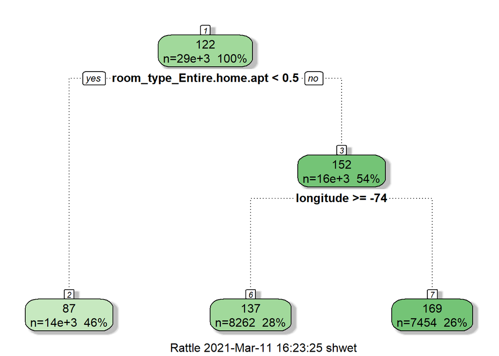

```
## CART
##
## 29217 samples
##    15 predictor
##
## No pre-processing
## Resampling: Bootstrapped (25 reps)
## Summary of sample sizes: 29217, 29217, 29217, 29217, 29217, 29217, ...
## Resampling results across tuning parameters:
##
##   cp          RMSE      Rsquared   MAE
##   0.02094603  43.15241  0.3952788  33.52195
##   0.04402718  44.29233  0.3628917  34.59656
##   0.33981562  48.91037  0.3366560  39.30988
##
## RMSE was used to select the optimal model using the smallest value.
## The final value used for the model was cp = 0.02094603.
```

```
## [1] "Training error: 43.5999012112265"
```

```
## [1] "Testing Error: 43.0039111337243"
```

Random Forest

[output not shown]

```
## Model Details:
## ==============
##
## H2ORegressionModel: drf
## Model Key:  DRF_model_R_1615487519427_23
## Model Summary:
##   number_of_trees number_of_internal_trees model_size_in_bytes min_depth
## 1             500                      500            69159541        20
##   max_depth mean_depth min_leaves max_leaves mean_leaves
## 1        20   20.00000       8926      12536 10992.41600
##
## H2ORegressionMetrics: drf
## ** Reported on training data. **
## ** Metrics reported on Out-Of-Bag training samples **
##
## MSE:  1438.852
## RMSE:  37.93221
## MAE:  28.33375
## RMSLE:  0.2988846
## Mean Residual Deviance :  1438.852
##
##
## H2ORegressionMetrics: drf
## ** Reported on validation data. **
##
## MSE:  1396.605
## RMSE:  37.37118
## MAE:  28.10567
## RMSLE:  0.2964236
## Mean Residual Deviance :  1396.605
##
##
##
##
## Scoring History:
##             timestamp   duration number_of_trees training_rmse training_mae
## 1 2021-03-11 16:23:32  0.123 sec               0            NA           NA
## 2 2021-03-11 16:23:32  0.410 sec               1      51.79508     37.22477
## 3 2021-03-11 16:23:32  0.673 sec               2      50.62073     36.57531
## 4 2021-03-11 16:23:33  0.929 sec               3      49.30973     35.71561
```

[output cut: 52 more lines]

```
## 1    0.257233
## 2    0.158010
## 3    0.151341
## 4    0.119877
## 5    0.071121
## 6    0.065193
## 7    0.049662
## 8    0.044754
## 9    0.038249
## 10   0.028872
## 11   0.005631
## 12   0.005068
## 13   0.003486
## 14   0.001016
## 15   0.000487
```

```
## H2ORegressionMetrics: drf
## ** Reported on validation data. **
##
## MSE:  1396.605
## RMSE:  37.37118
## MAE:  28.10567
## RMSLE:  0.2964236
## Mean Residual Deviance :  1396.605
```

```
## [1] "R2 Random Forest :  0.541362740248253"
```

To improve the execution speed of the model in R, used the H20 package to build the models. H2O is a Java Virtual Machine that is optimized for doing “in memory” processing of distributed, parallel machine learning algorithms on clusters.

```
##            used  (Mb) gc trigger  (Mb) max used  (Mb)
## Ncells  3482623 186.0    6609254 353.0  6609254 353.0
## Vcells 13192987 100.7   23567816 179.9 23567816 179.9
```

Although the prediction accuracy obtained is better than decision tree, the main drawback of Random Forests is the model size and their complexity. They are much harder and time-consuming to construct. They also require more computational resources; it took hundreds of megabytes of memory and was slow to evaluate. Another point that some might find a concern is that random forest models are black boxes that are very hard to interpret. Lastly, we would build the Gradient Boosting Model.

Gradient Boosting

[output not shown]

```
## Model Details:
## ==============
##
## H2ORegressionModel: gbm
## Model Key:  GBM_model_R_1615487519427_24
## Model Summary:
##   number_of_trees number_of_internal_trees model_size_in_bytes min_depth
## 1             500                      500              117017         0
##   max_depth mean_depth min_leaves max_leaves mean_leaves
## 1         5    2.68000          1         32    13.74800
##
## H2ORegressionMetrics: gbm
## ** Reported on training data. **
##
## MSE:  1235.743
## RMSE:  35.15313
## MAE:  26.26761
## RMSLE:  0.2763139
## Mean Residual Deviance :  1235.743
##
##
## H2ORegressionMetrics: gbm
## ** Reported on validation data. **
##
## MSE:  1383.938
## RMSE:  37.20131
## MAE:  27.97787
## RMSLE:  0.2949424
## Mean Residual Deviance :  1383.938
##
##
##
##
## Scoring History:
##             timestamp   duration number_of_trees training_rmse training_mae
## 1 2021-03-11 16:26:20  0.034 sec               0      55.54721     46.36954
## 2 2021-03-11 16:26:20  0.081 sec               1      52.98798     44.04491
## 3 2021-03-11 16:26:20  0.118 sec               2      50.80491     42.06825
## 4 2021-03-11 16:26:20  0.158 sec               3      48.95042     40.35797
## 5 2021-03-11 16:26:20  0.203 sec               4      47.37429     38.86243
```

[output cut: 44 more lines]

```
## 1    0.566801
## 2    0.156602
## 3    0.115445
## 4    0.045712
## 5    0.031052
## 6    0.028780
## 7    0.027086
## 8    0.019047
## 9    0.003415
## 10   0.003242
## 11   0.000788
## 12   0.000782
## 13   0.000756
## 14   0.000493
## 15   0.000000
```

```
## H2ORegressionMetrics: gbm
## ** Reported on validation data. **
##
## MSE:  1383.938
## RMSE:  37.20131
## MAE:  27.97787
## RMSLE:  0.2949424
## Mean Residual Deviance :  1383.938
```

```
## [1] "R2 Gradient Boost :  0.545522723383396"
```

```
##            used  (Mb) gc trigger  (Mb) max used  (Mb)
## Ncells  3484698 186.2    6609254 353.0  6609254 353.0
## Vcells 13207834 100.8   23567816 179.9 23567816 179.9
```

[output not shown]